# midterm

Author

Jessica Villanueva

```r
# install.packages("scales")
library(tidyverse)
library(scales)
```

## 1. Warm up - 7 pts total

#### 1.1 - 2 pts

Read in the border crossing data into a tibble / data frame called `border`. How many columns and rows are there?

> There are 10 columns and 394866 rows.

```r
border <- read_csv("/Users/Jessica/Downloads/STAT_128/midterm/Border_Crossing_Entry_Data.csv")
dim(border)
```

```
[1] 394866     10
```

```r
border
```

```
# A tibble: 394,866 × 10
   `Port Name`   State `Port Code` Border Date  Measure Value Latitude Longitude
   <chr>         <chr> <chr>       <chr>  <chr> <chr>   <dbl>    <dbl>     <dbl>
 1 Roma          Texas 2310        US-Me… Dec … Buses      46     26.4     -99.0
 2 Del Rio       Texas 2302        US-Me… Dec … Trucks   6552     29.3    -101.
 3 Roma          Texas 2310        US-Me… Nov … Trucks   3753     26.4     -99.0
 4 Douglas       Ariz… 2601        US-Me… Oct … Buses      13     31.3    -110.
 5 Beecher Falls Verm… 0206        US-Ca… Aug … Trucks    422     45.0     -71.5
 6 Laredo        Texas 2304        US-Me… Aug … Buses    2843     27.5     -99.5
 7 Morgan        Mont… 3319        US-Ca… Aug … Trucks     20     49      -108.
 8 Hidalgo       Texas 2305        US-Me… Aug … Trucks  59677     26.1     -98.3
 9 Raymond       Mont… 3301        US-Ca… Jul … Buses       3     49.0    -105.
10 Roma          Texas 2310        US-Me… Jul … Bus Pa…   949     26.4     -99.0
# ℹ 394,856 more rows
# ℹ 1 more variable: Point <chr>
```

#### 1. - 2 pts

Change `border` by renaming the `Port Name` column to `port_name` to make it easier to work with in the questions that follow.

```r
border <- border |>
  rename(port_name = "Port Name")
```

#### 1. - 2 pts

Add a new column to `border` called `Date2` by converting the `Date` column from a character vector into a date.

```r
# Hint my() means "month-year", similar to ymd() is "year-month-day"
# Convert to date:
my("Oct 2024")
```

```
[1] "2024-10-01"
```

```r
border <- border |>
  mutate(Date2 = my(Date))
```

#### 1. - 1 pts

What time period does this data cover? Answer using the `Date2` column you created above.

```r
range(border$Date2)
```

```
[1] "1996-01-01" "2024-08-01"
```

The data covers a span of time from January 1996 to August 2024.

## 2. Analysis - 11 pts total

#### 2. - 1 pts

Does `"Sacramento"` appear in the data set?

> yes or no?

```r
border |>
  filter(port_name == "Sacramento" | State == "Sacramento")
```

```
# A tibble: 0 × 11
# ℹ 11 variables: port_name <chr>, State <chr>, Port Code <chr>, Border <chr>,
#   Date <chr>, Measure <chr>, Value <dbl>, Latitude <dbl>, Longitude <dbl>,
#   Point <chr>, Date2 <date>
```

No, Sacramento does not appear in the data set, in neither of the columns that hold place names.

#### 2. - 2 pts

What is the most frequently occurring value in the `Measure` column?

```r
border |>
  group_by(Measure) |>
  summarize(count = n()) |>
  arrange(desc(count))
```

```
# A tibble: 12 × 2
   Measure                     count
   <chr>                       <int>
 1 Personal Vehicles           37151
 2 Personal Vehicle Passengers 37125
 3 Trucks                      36107
 4 Truck Containers Empty      35937
 5 Truck Containers Loaded     35457
 6 Pedestrians                 32299
 7 Buses                       31391
 8 Bus Passengers              31375
 9 Trains                      29657
10 Rail Containers Empty       29635
11 Rail Containers Loaded      29544
12 Train Passengers            29188
```

The most frequently occurring value in the Measure column of the tibble is “Personal Vehicles” with 37,151 mentions in the data set.

#### 2. - 2 pts

When and where were the most pedestrian (on foot) border crossings? Use `head()` to show the top 6.

```r
border |>
  select(Date2, Measure, port_name, State, Border, Value) |>
  filter(Measure == "Pedestrians") |>
  arrange(desc(Value)) |>
  head(n = 6)
```

```
# A tibble: 6 × 6
  Date2      Measure     port_name  State      Border             Value
  <date>     <chr>       <chr>      <chr>      <chr>              <dbl>
1 2001-07-01 Pedestrians San Ysidro California US-Mexico Border 1227544
2 2001-08-01 Pedestrians San Ysidro California US-Mexico Border 1143120
3 2001-03-01 Pedestrians San Ysidro California US-Mexico Border 1114188
4 2001-05-01 Pedestrians San Ysidro California US-Mexico Border 1109375
5 2001-04-01 Pedestrians San Ysidro California US-Mexico Border 1107608
6 2001-06-01 Pedestrians San Ysidro California US-Mexico Border 1093971
```

At the US-Mexico Border, the most pedestrians crossings occur at San Ysidro in California, with the most people crossing the border occurring in July & August of 2001. Subsequent months are March, May, April, and June in order of how many people crossed, from greatest to least.

#### 2. - 4 pts

Plot the total number of car passengers crossing the border each month.

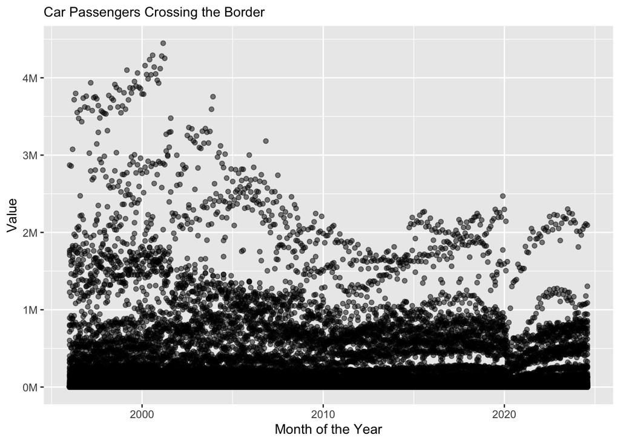

```r
border |>
  filter(Measure == "Personal Vehicle Passengers") |>
  ggplot(aes(x = Date2, y = Value)) +
  geom_point(alpha = 0.5) +
  scale_y_continuous(labels = label_number(
    scale = 1e-6, suffix = "M", accuracy = 1)) +
  labs(subtitle = "Car Passengers Crossing the Border",
       x = "Month of the Year")
```

#### 2. - 2 pts

Comment on the above plot. Approximately how many car passengers cross the border each month? In what year does the pattern seem to change? What happened during the COVID pandemic in early 2020?

> The number of car passengers varies between 0 and 4.5 million. There were a large quantity of crossings in the 2000s, but by 2010 the crossings saw a decline. In early 2020, there was a sharp decrease in quantity of crossings when the pandemic hit.

## 3. Modeling - 9 pts total

#### 3. - 2 pts

Create a new tibble `nf` containing only the counts of pedestrians crossing in Buffalo Niagara Falls between 2014 and 2018, inclusive. Use `head()` to show the first 6 rows.

```r
nf <- border |>
  filter(Measure == "Pedestrians" & port_name == "Buffalo Niagara Falls"
         & year(Date2) >= 2014 & year(Date2) <= 2018)
nf |>
  head(n = 6)
```

```
# A tibble: 6 × 11
  port_name      State `Port Code` Border Date  Measure Value Latitude Longitude
  <chr>          <chr> <chr>       <chr>  <chr> <chr>   <dbl>    <dbl>     <dbl>
1 Buffalo Niaga… New … 0901        US-Ca… Dec … Pedest…  9163     43.1     -79.1
2 Buffalo Niaga… New … 0901        US-Ca… Sep … Pedest… 39998     43.1     -79.1
3 Buffalo Niaga… New … 0901        US-Ca… Jul … Pedest… 63207     43.1     -79.1
4 Buffalo Niaga… New … 0901        US-Ca… Apr … Pedest… 15526     43.1     -79.1
5 Buffalo Niaga… New … 0901        US-Ca… Sep … Pedest… 43367     43.1     -79.1
6 Buffalo Niaga… New … 0901        US-Ca… Feb … Pedest…  6812     43.1     -79.1
# ℹ 2 more variables: Point <chr>, Date2 <date>
```

#### 2. - 2 pts

Create a plot of the above data, with date on the x axis and number of pedestrians on the y axis.

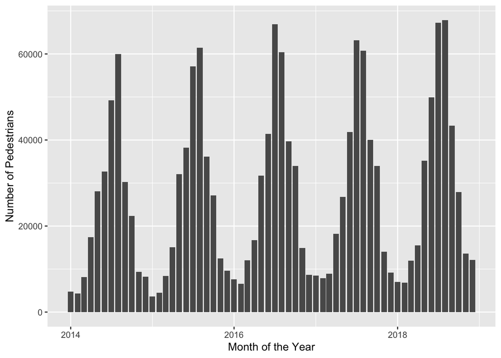

```r
nf |>
  ggplot(aes(x = Date2, y = Value)) +
  geom_col() +
  labs(x = "Month of the Year", y = "Number of Pedestrians")
```

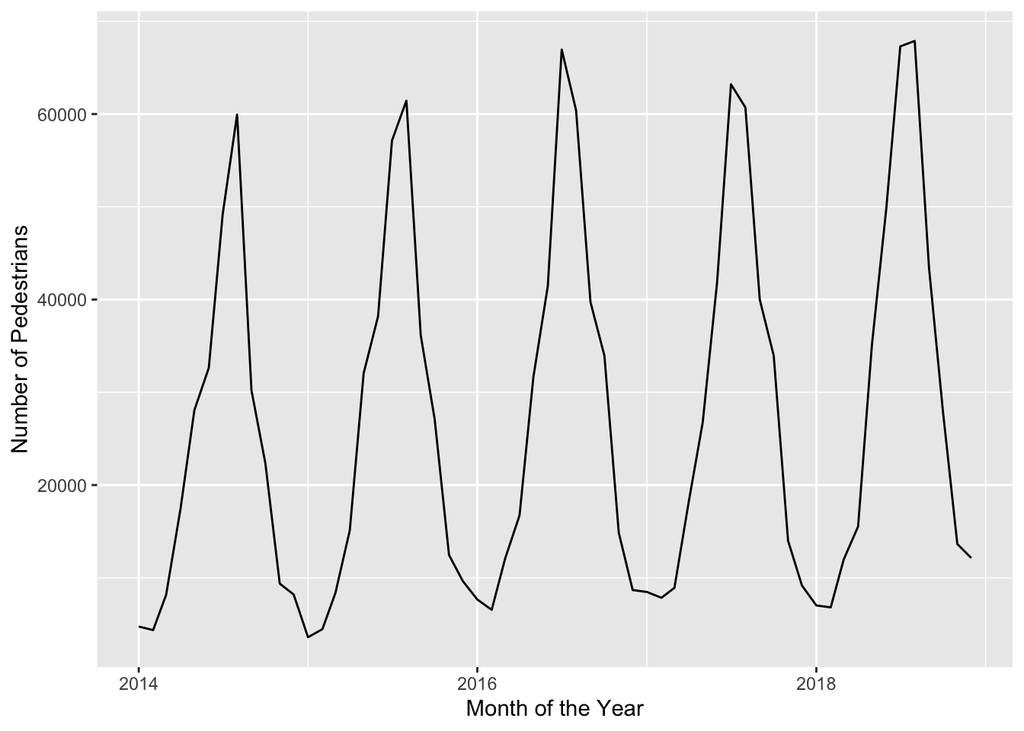

```r
nf |>
  ggplot(aes(x = Date2, y = Value)) +
  geom_line() +
  labs(x = "Month of the Year", y = "Number of Pedestrians")
```

#### 2. - 2 pts

Let $y$ be the number of pedestrians crossing in the `nf` data above, `x` be the number of the month (January = 1, February = 2), etc. Let $a = \frac{2\pi}{12}$ for an annual cycle. Fit the following statistical model:

$$y = \beta_0 + \beta_1 \cos(ax)$$

```r
# Hint: Use month() to extract the month as a number.
# month(ymd("2024-10-14"))

a <- 2*pi/12

model <- lm(Value ~ cos(a * month(Date2)), nf)
nf$predictions <- predict(model, nf)

coef(model)
```

```
          (Intercept) cos(a * month(Date2))
             26879.47             -19284.18
```

Show that the fitted coefficients are:

$$y = 26,879.47 -19,284.18 \cos(ax)$$

#### 2. - 2 pts

Create a plot of the above data, with date on the x axis and number of pedestrians on the y axis. Add a visually distinct line for the predictions from the model.

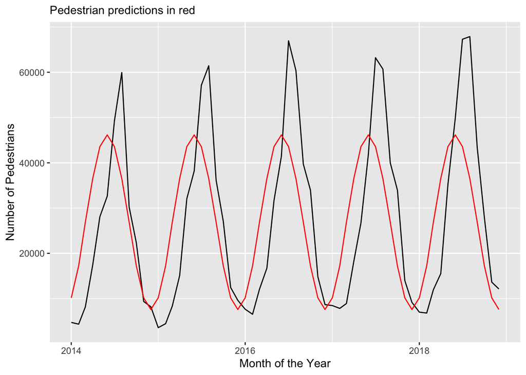

```r
ggplot(nf, aes(x = Date2, y = Value)) +
  geom_line() +
  geom_line(aes(x = Date2, y = predictions), color = "red") +
  labs(subtitle = "Pedestrian predictions in red",
       x = "Month of the Year", y = "Number of Pedestrians")
```

#### 2. - 1 pts

Comment on the above graph. Where does the model appear to be doing poorly, and how could we improve it?

The model, in general, is shortcoming in its predictions. It doesn’t predict the highs well and it can be shifted a bit to the right to match the true values of the graph. The lows are pretty accurate though.

## 4. Open Ended - 4 pts

Ask your own question of the border crossing data, and answer it using a data visualization.

Answers vary

On average, how many border crossings are there every month of the year? Which month seems to have the most?

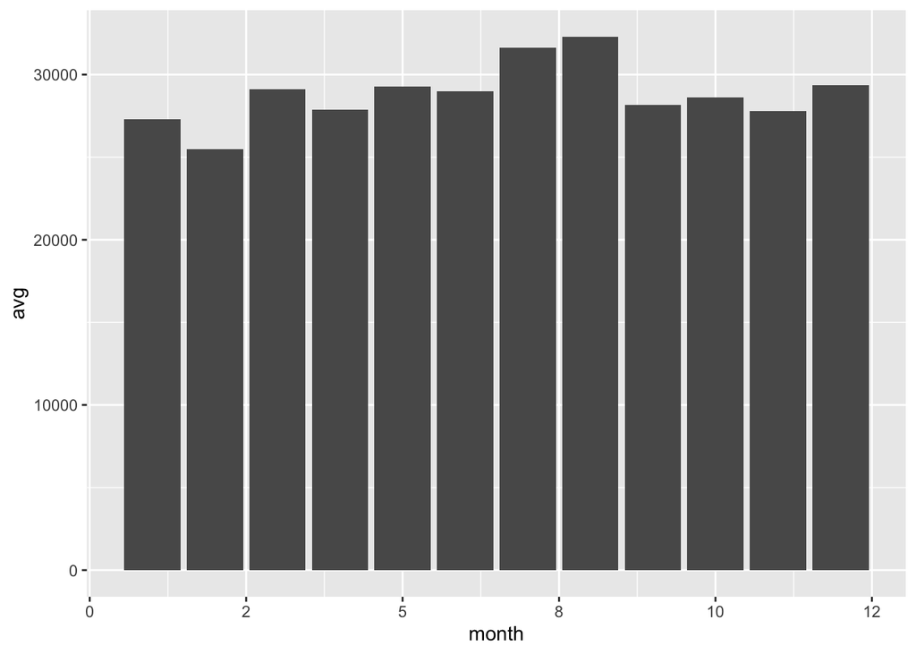

```r
border |>
  group_by(month = month(Date2)) |>
  summarize(avg = mean(Value)) |>
  ggplot(aes(x = month, y = avg)) +
  geom_col() +
  scale_x_continuous(labels = label_number(
    scale = 1, accuracy = 1))
```